# FDA_project Air Quality Analytics

05/12/2021

### 1. Importing the dataset

```r
library(tidyverse)
library(GGally)
library(Metrics)
```

```r
library(ggplot2)
library(ISLR)
library(mosaic)
library(Hmisc)
library(ggcorrplot)
data<-read.csv("Air_Pollution.csv")
summary(data)
```

```
##    stn_code         sampling_date         state             location
##  Length:435739      Length:435739      Length:435739      Length:435739
##  Class :character   Class :character   Class :character   Class :character
##  Mode  :character   Mode  :character   Mode  :character   Mode  :character
##
##
##
##
##     agency              type                so2              no2
##  Length:435739      Length:435739      Min.   :  0.00   Min.   :  0.00
##  Class :character   Class :character   1st Qu.:  5.00   1st Qu.: 14.00
##  Mode  :character   Mode  :character   Median :  8.00   Median : 22.00
##                                        Mean   : 10.83   Mean   : 25.81
##                                        3rd Qu.: 13.70   3rd Qu.: 32.20
##                                        Max.   :909.00   Max.   :876.00
##                                        NA's   :34643    NA's   :16230
##       rspm             spm         location_monitoring_station     pm2_5
##  Min.   :   0.0   Min.   :   0.0   Length:435739               Min.   :  3.0
##  1st Qu.:  56.0   1st Qu.: 111.0   Class :character            1st Qu.: 24.0
##  Median :  90.0   Median : 187.0   Mode  :character            Median : 32.0
##  Mean   : 108.8   Mean   : 220.8                               Mean   : 40.8
##  3rd Qu.: 142.0   3rd Qu.: 296.0                               3rd Qu.: 46.0
##  Max.   :6307.0   Max.   :3380.0                               Max.   :504.0
##  NA's   :40219    NA's   :237384                               NA's   :426425
##      date
##  Length:435739
##  Class :character
##  Mode  :character
##
##
##
##
```

### 2. Data cleaning (Analysis)

```r
cat("Printing the % of null values in each column\n")
```

```
## Printing the % of null values in each column
```

```r
lapply(data,function(x) { length(which(is.na(x)))*100/nrow(data)})
```

```
## $stn_code
## [1] 33.06429
##
## $sampling_date
## [1] 0
##
## $state
## [1] 0
##
## $location
## [1] 0
##
## $agency
## [1] 34.30448
##
## $type
## [1] 1.236979
##
## $so2
## [1] 7.950402
##
## $no2
## [1] 3.724707
##
## $rspm
## [1] 9.230067
##
## $spm
## [1] 54.47848
##
## $location_monitoring_station
## [1] 6.308363
##
## $pm2_5
## [1] 97.86248
##
## $date
## [1] 0.0009179807
```

### 3. Furthut cleaning

##### It is evident that there are so many null values in the given dataset

- The data contains 2 date columns, so let us omit one
- Removing columns having more than 50% of null values
- Remove the serial number

```r
data=subset(data,select=-c(sampling_date,stn_code,spm,pm2_5))
head(data,n=10)
```

```
##             state  location agency                               type so2  no2
## 1  Andhra Pradesh Hyderabad   <NA> Residential, Rural and other Areas 4.8 17.4
## 2  Andhra Pradesh Hyderabad   <NA>                    Industrial Area 3.1  7.0
## 3  Andhra Pradesh Hyderabad   <NA> Residential, Rural and other Areas 6.2 28.5
## 4  Andhra Pradesh Hyderabad   <NA> Residential, Rural and other Areas 6.3 14.7
## 5  Andhra Pradesh Hyderabad   <NA>                    Industrial Area 4.7  7.5
## 6  Andhra Pradesh Hyderabad   <NA> Residential, Rural and other Areas 6.4 25.7
## 7  Andhra Pradesh Hyderabad   <NA> Residential, Rural and other Areas 5.4 17.1
## 8  Andhra Pradesh Hyderabad   <NA>                    Industrial Area 4.7  8.7
## 9  Andhra Pradesh Hyderabad   <NA> Residential, Rural and other Areas 4.2 23.0
## 10 Andhra Pradesh Hyderabad   <NA>                    Industrial Area 4.0  8.9
##    rspm location_monitoring_station       date
## 1    NA                        <NA> 01-02-1990
## 2    NA                        <NA> 01-02-1990
## 3    NA                        <NA> 01-02-1990
## 4    NA                        <NA> 01-03-1990
## 5    NA                        <NA> 01-03-1990
## 6    NA                        <NA> 01-03-1990
## 7    NA                        <NA> 01-04-1990
## 8    NA                        <NA> 01-04-1990
## 9    NA                        <NA> 01-04-1990
## 10   NA                        <NA> 01-05-1990
```

### 4. Viewing the number of unique values in each column

```r
lapply(data,function(x) { length(unique(x))})
```

```
## $state
## [1] 34
##
## $location
## [1] 304
##
## $agency
## [1] 65
##
## $type
## [1] 11
##
## $so2
## [1] 4198
##
## $no2
## [1] 6865
##
## $rspm
## [1] 6066
##
## $location_monitoring_station
## [1] 992
##
## $date
## [1] 5068
```

### 5. Removal of outliers in so2 variable

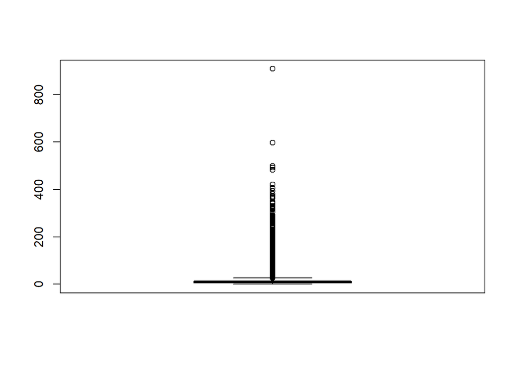

```r
outliers<-boxplot(data$so2)$out
```

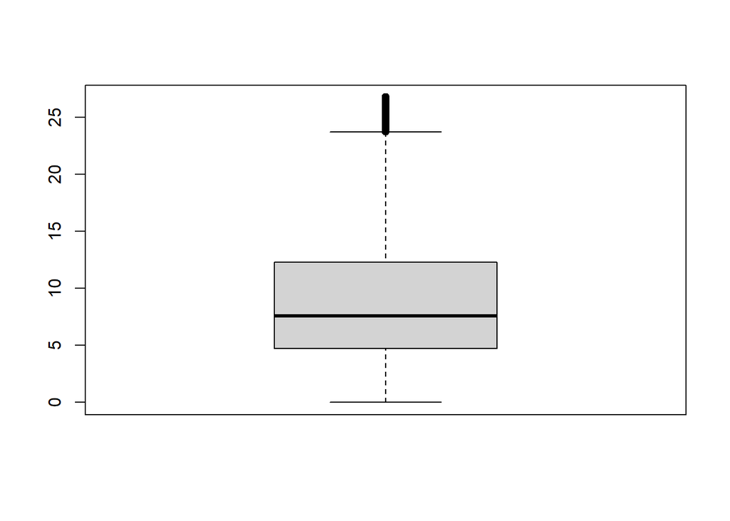

```r
data<-data[-which(data$so2 %in% outliers),]
boxplot(data$so2)
```

### 6. Removal of outliers in no2 variable

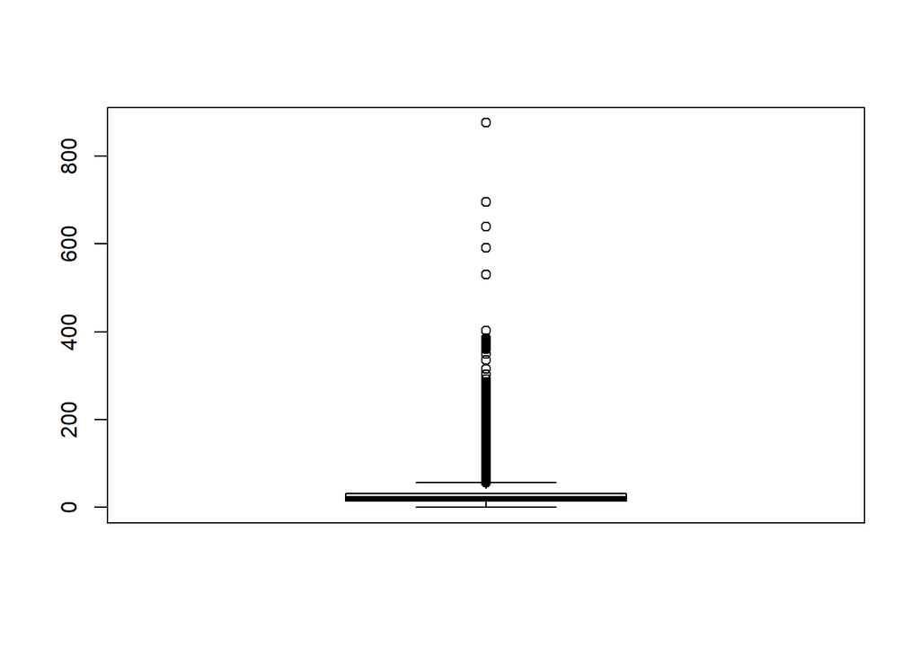

```r
outliers<-boxplot(data$no2)$out
```

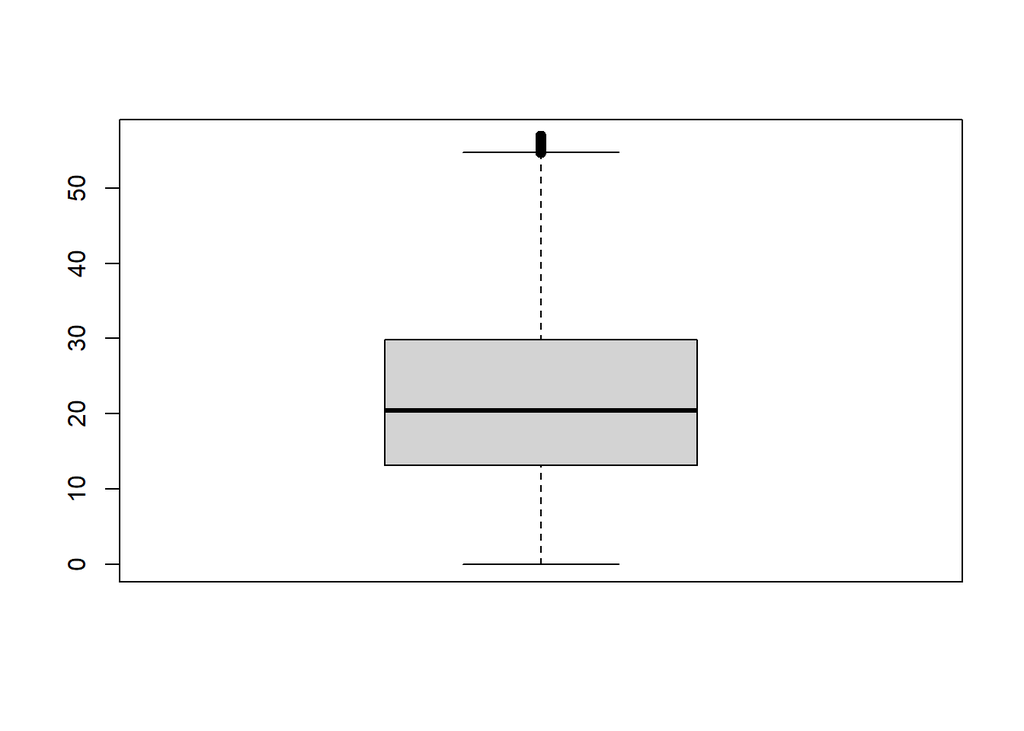

```r
data<-data[-which(data$no2 %in% outliers),]
boxplot(data$no2)
```

### 7. Removal of outliers in rspm variable

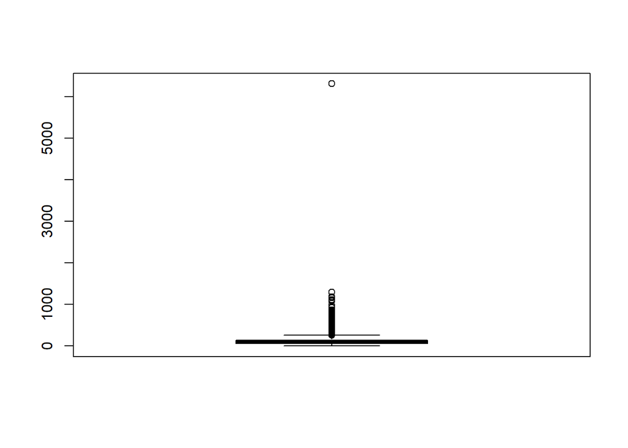

```r
outliers<-boxplot(data$rspm)$out
```

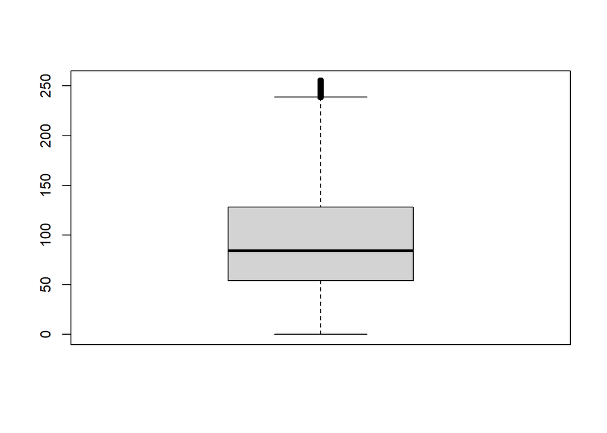

```r
data<-data[-which(data$rspm %in% outliers),]
boxplot(data$rspm)
```

### Imputing numerical data (Using median values to impute in numerical column)

```r
data%>%summarise(avg=mean(data$so2,na.rm = TRUE),md=median(data$so2,na.rm = TRUE))
```

```
##        avg  md
## 1 8.815336 7.2
```

```r
data%>%summarise(avg=mean(data$no2,na.rm = TRUE),md=median(data$no2,na.rm = TRUE))
```

```
##        avg md
## 1 21.93056 20
```

```r
data%>%summarise(avg=mean(data$rspm,na.rm = TRUE),md=median(data$rspm,na.rm = TRUE))
```

```
##        avg md
## 1 96.08818 84
```

```r
data <- data%>%
  mutate(so2=replace(so2,is.na(so2),median(so2,na.rm = TRUE)))
cat("Sum of null values in so2 column",sum(is.na(data$so2)),"\n")
```

```
## Sum of null values in so2 column 0
```

```r
data <- data%>%
  mutate(no2=replace(no2,is.na(no2),median(no2,na.rm = TRUE)))
cat("Sum of null values in no2 column",sum(is.na(data$no2)),"\n")
```

```
## Sum of null values in no2 column 0
```

```r
data <- data%>%
  mutate(rspm=replace(rspm,is.na(rspm),median(rspm,na.rm = TRUE)))
cat("Sum of null values in rspm column",sum(is.na(data$rspm)),"\n")
```

```
## Sum of null values in rspm column 0
```

### Impute categorical data (using mode to impute in categorical column and viewing the number of null values in each column)

```r
# Type
val <- unique(data$type[!is.na(data$type)])
my_mode <- val[which.max(tabulate(match(data$type, val)))]
data$type[is.na(data$type)] <- my_mode
# Location
val <- unique(data$location[!is.na(data$location)])
my_mode <- val[which.max(tabulate(match(data$location, val)))]
data$location[is.na(data$location)] <- my_mode
# Agency
val <- unique(data$agency[!is.na(data$agency)])
my_mode <- val[which.max(tabulate(match(data$agency, val)))]
data$agency[is.na(data$agency)] <- my_mode
# location_monitoring_station
val <- unique(data$location_monitoring_station[!is.na(data$location_monitoring_station)])
my_mode <- val[which.max(tabulate(match(data$location_monitoring_station, val)))]
data$location_monitoring_station[is.na(data$location_monitoring_station)] <- my_mode

lapply(data,function(x) { length(which(is.na(x)))*100/nrow(data)})
```

```
## $state
## [1] 0
##
## $location
## [1] 0
##
## $agency
## [1] 0
##
## $type
## [1] 0
##
## $so2
## [1] 0
##
## $no2
## [1] 0
##
## $rspm
## [1] 0
##
## $location_monitoring_station
## [1] 0
##
## $date
## [1] 0.001048322
```

#### Graphs and analytics

```r
print("States where air pollution is tested")
```

```
## [1] "States where air pollution is tested"
```

```r
table(data$state)
```

```
##
##       Andhra Pradesh    Arunachal Pradesh                Assam
##                25702                   90                18988
##                Bihar           Chandigarh         Chhattisgarh
##                 1476                 8342                 7358
## Dadra & Nagar Haveli          Daman & Diu                Delhi
##                  634                  781                 5239
##                  Goa              Gujarat              Haryana
##                 6081                19920                 2814
##     Himachal Pradesh      Jammu & Kashmir            Jharkhand
##                22458                 1285                 3401
##            Karnataka               Kerala       Madhya Pradesh
##                15971                24415                17933
##          Maharashtra              Manipur            Meghalaya
##                47132                   76                 3559
##              Mizoram             Nagaland               Odisha
##                 5331                 2450                19113
##           Puducherry               Punjab            Rajasthan
##                 3554                22917                21886
##               Sikkim           Tamil Nadu            Telangana
##                    1                19631                 3829
##        Uttar Pradesh          Uttarakhand          Uttaranchal
##                35554                 1581                  208
##          West Bengal
##                11852
```

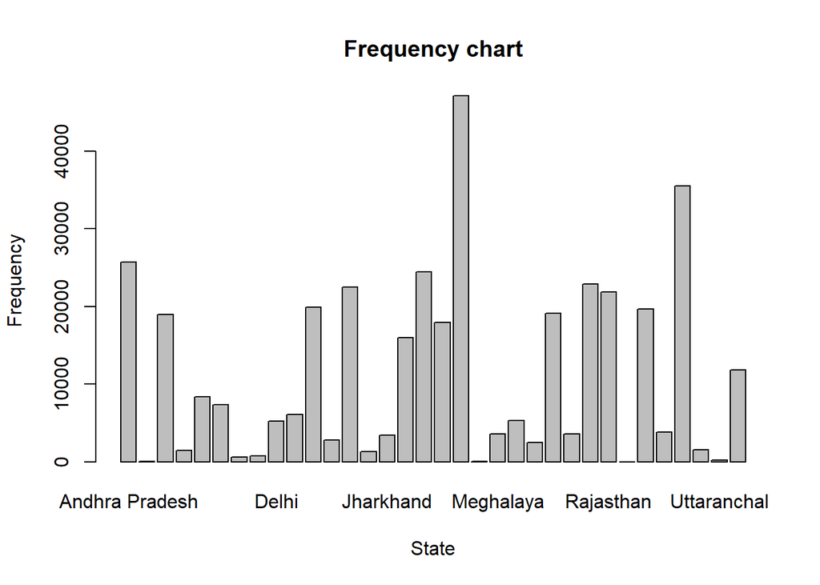

```r
barplot(table(data$state),xlab="State",ylab="Frequency",main="Frequency chart")
```

```r
print("Location where air pollution is tested")
```

```
## [1] "Location where air pollution is tested"
```

```r
table(data$location)
```

```
##
##               Agra          Ahmedabad             Aizawl              Akola
##               5965               6047               3493               1048
##          Alappuzha          Allahabad              Alwar              Amlai
##               1512               1067               2778                119
##              Amona           Amravati           Amritsar         Ananthapur
##                299               2456               1304                324
##              Angul         Ankleshwar         ANKLESHWAR          Anklesvar
##               2346               1117                167                881
##             Anpara            Asansol           Assanora         Aurangabad
##               1687                806                298               1809
##    Aurangabad (MS)              Baddi           Badlapur           Balasore
##               1173               2932                194               1239
##          Bangalore           Bareilly             Baroda        Barrackpore
##               5821                523                518                386
##           Baruipur           Bathinda            Belgaum          Berhampur
##                 43                878                711                808
##            Bharuch             Bhilai       Bhilai Nagar             Bhopal
##                350               1820               1173               3193
##       Bhubaneshwar        Bhubaneswar               Bhuj           Bicholim
##               1294               2366                 24                300
##              Bidar            Bijapur           Bilaspur             Bombay
##                 88                 67                238                280
##         Bongaigaon           Byrnihat           Calcutta           Champhai
##               1674                216                293                626
##         Chandarpur         Chandigarh         Chandrapur            Chennai
##                 72               8342               3153               6466
##         Chhindwara        Chitradurga           Chittoor        Chittorgarh
##                125                296               1001                 25
##             Cochin              Codli         Coimbatore          Cuddalore
##                938                300               3150                651
##           Cuncolim          Curchorem            Cuttack              Daman
##                103                307               1870                647
##  Daman Diu & Nagar             Damtal            DANKUNI            Daranga
##                165               2916                 85                399
##          Davangere              Dawki          Dehradoon           Dehradun
##                644                510                196                723
##              Delhi          Dera Baba         Dera Bassi              Dewas
##               5239                608               2427               1677
##            Dhanbad        Dharamshala            Dharwad          Dibrugarh
```

[output cut: 98 more lines]

```
##                986               1179               1921                366
##             Tumkur               Tura          Turicorin          Tuticorin
##                195                432                 40                243
##            Udaipur             Ujjain         Ulhasnagar           ULUBERIA
##               3279               2323                330                 89
##            Umsning                Una              Unnao              Usgao
##                 68               1153                360                286
##           Vadodara               Vapi               VAPI           Varanasi
##               2870               1935                 24               1617
##              Vasco         Vijayawada      Visakhapatnam     Vishakhapatnam
##               1379               2078               6797                240
##       Vizianagaram           Warangal            Wayanad     West Singhbhum
##                278                624                512                 90
##       Yamuna Nagar        Yamunanagar
##                196                178
```

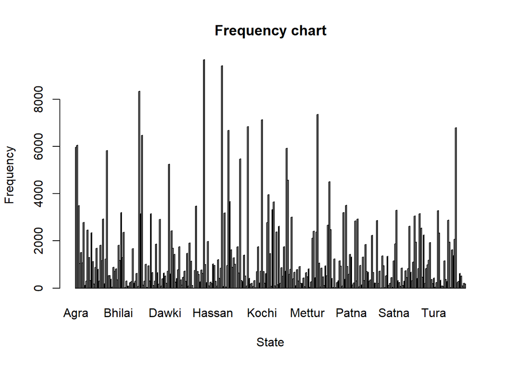

```r
barplot(table(data$location),xlab="State",ylab="Frequency",main="Frequency chart")
```

```r
print("Location monitoring station where air pollution is tested")
```

```
## [1] "Location monitoring station where air pollution is tested"
```

```r
table(data$location_monitoring_station)
```

```
##
##                                                                            A-1 Platters
##                                                                                     241
##                                                                   A-1,Platers, Amritsar
##                                                                                     358
##                                                                              A S School
##                                                                                     356
##                                                                            ABIDS Circle
##                                                                                     338
##                                    ABIDS Circle General Post Office Building, Hyderabad
##                                                                                     360
##        Above the Fire Brigade Station, Near Birth 5A & 6A of Mormugao,Port Trust, Vasco
##                                                                                     440
##                                                                         AC Office Bldg.
##                                                                                     596
##                                                            AC Office Building, Parwanoo
##                                                                                     993
## Administrative Building of M/s Srini Pharmaceuticals Ltd, Choutuppal, Nalgonda District
##                                                                                     169
##                                                                          Adyar, Chennai
##                                                                                     302
## Agriculture University, C.S. Azad Agriculatural University, Crop Physiological Departme
##                                                                                       5
##                                                                                     AHC
##                                                                                     670
##                                                                                Ahirpara
##                                                                                      79
##                                                                        Ahirpara, Khurja
##                                                                                     372
##                                    Ahmadnagar Town Hall Colony Gulab Road, Rai Bareilly
##                                                                                     334
##                                                                                  Airoli
##                                                                                     291
##                                                                            Airport Road
##                                                                                     110
##                                                                             Ajmeri Gate
##                                                                                     477
##                                                                      Ajmeri Gate,Jaipur
##                                                                                     637
##                                          AKVN Office, Industrial Area Mandideep, Raisen
```

[output cut: 1922 more lines]

```
##                                                                                      24
##                                                                           Yatayat Thana
##                                                                                     283
##                                            Yatayat Thana, Near Jai Stambh Chowk, Raipur
##                                                                                      82
##                                                                           Yeshwanthpura
##                                                                                     343
##                                                                Yeshwanthpura, Bangalore
##                                                                                     476
##                                                                                Zoo Park
##                                                                                     418
##                                                                     Zoo Park, Hyderabad
##                                                                                     379
##                             Zydas Infratech-Pharmez matoda GIDC NH-8A, Changodar,SANAND
##                                                                                      23
```

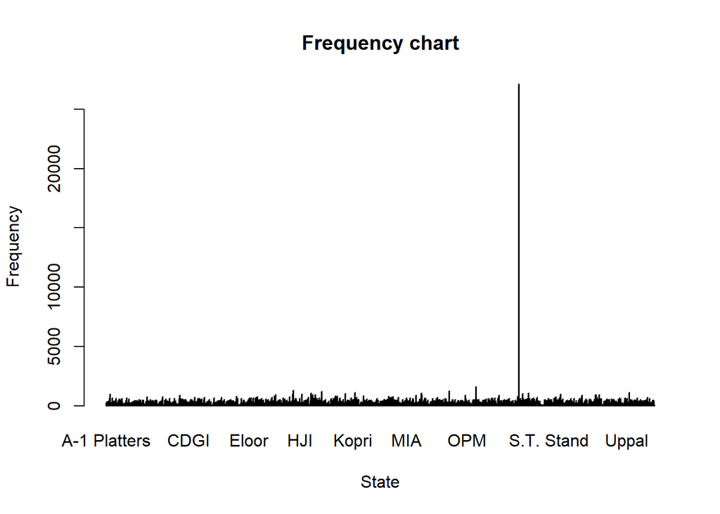

```r
barplot(table(data$location_monitoring_station),xlab="State",ylab="Frequency",main="Frequency chart")
```

```r
print("Agency which tested the air pollution")
```

```
## [1] "Agency which tested the air pollution"
```

```r
table(data$agency)
```

```
##
##                                Andhra Pradesh  Pollution Control Board
##                                                                    515
##                           Andhra Pradesh State Pollution Control Board
##                                                                  18693
##                        Arunachal Pradesh State Pollution Control Board
##                                                                     90
##                                                                   ASPB
##                                                                    212
##                                    Assam State Pollution Control Board
##                                                                  13216
##                                          Bihar Pollution Control Board
##                                                                    288
##                                     Bihar Sate Pollution Control Board
##                                                                    577
##                                        Central Pollution Control Board
##                                                                   5308
##                                 Chandigarh Pollution Control Committee
##                                                                   4468
##                             Chattisgarh Environment Conservation Board
##                                                                   3800
##                                                                   CMEC
##                                                                    168
##            Daman Diu, Dadra & Nagar Heveli Pollution Control Committee
##                                                                    636
##                                                                   ESPU
##                                                                     20
##                                            Goa Pollution Control Board
##                                                                    160
##                                      Goa State Pollution Control Board
##                                                                   4986
##                                        Gujarat Pollution Control Board
##                                                                   1257
##                                  Gujarat State Pollution Control Board
##                                                                   8491
##                                        Haryana Pollution Control Board
##                                                                    124
##                                  Haryana State Pollution Control Board
##                                                                   1521
##                               Himachal Pradesh  Pollution Control Boar
```

[output cut: 74 more lines]

```
##                                                                    226
##                            Uttar Pradesh State Pollution Control Board
##                                                                  18909
##         Uttarakhand Environment Protection and Pollution Control Board
##                                                                   1581
##                         Visveshwaraya National Institute Of Technology
##                                                                   2173
##                                                                   VRCE
##                                                                     61
##                              Walchand Institute of Technology, Solapur
##                                                                   1578
##                                    West Bengal Pollution Control Board
##                                                                    148
##                              West Bengal State Pollution Control Board
##                                                                   6862
```

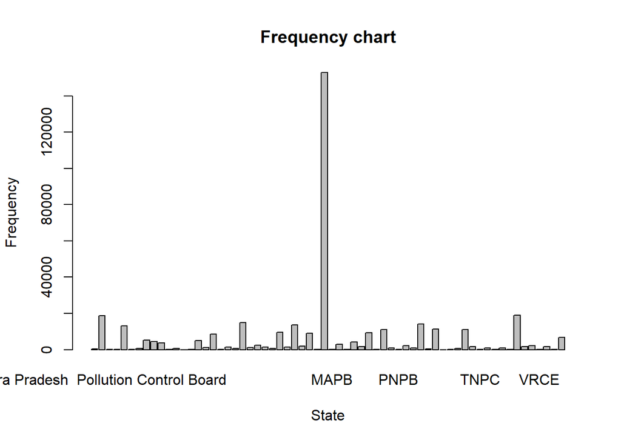

```r
barplot(table(data$agency),xlab="State",ylab="Frequency",main="Frequency chart")
```

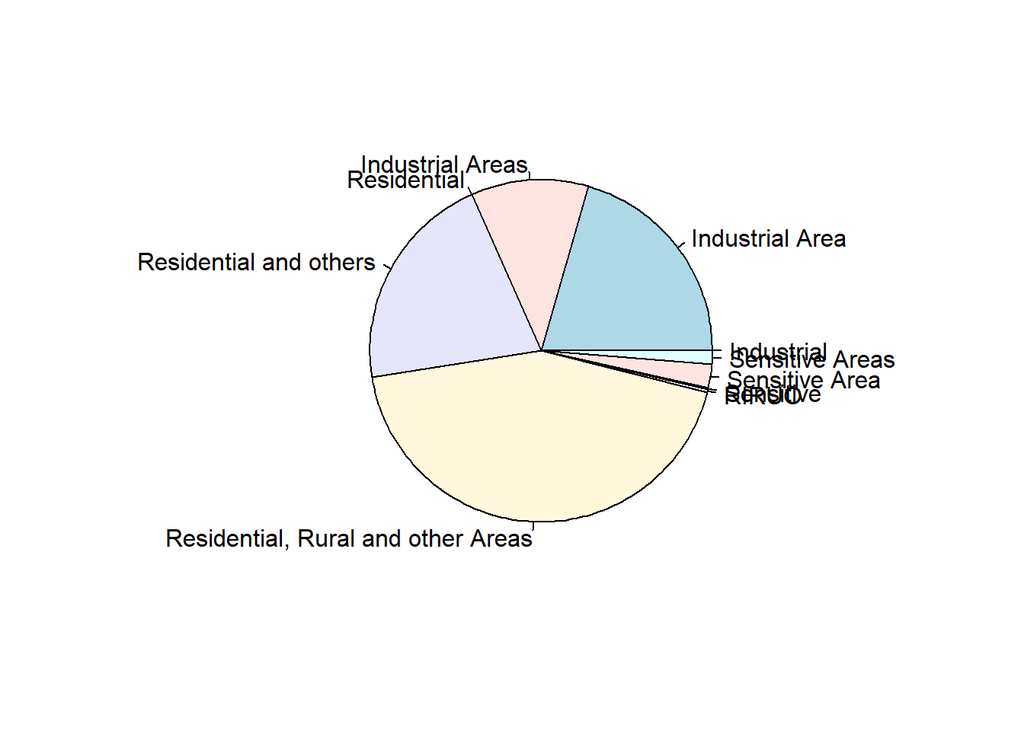

```r
pie(table(data$type))
```

### Correlation plot (Correlation is not relavent since the corr is not greater than 0.7 and not less than -0.7, this cannot be used for prediction since none of the variable is dependent)

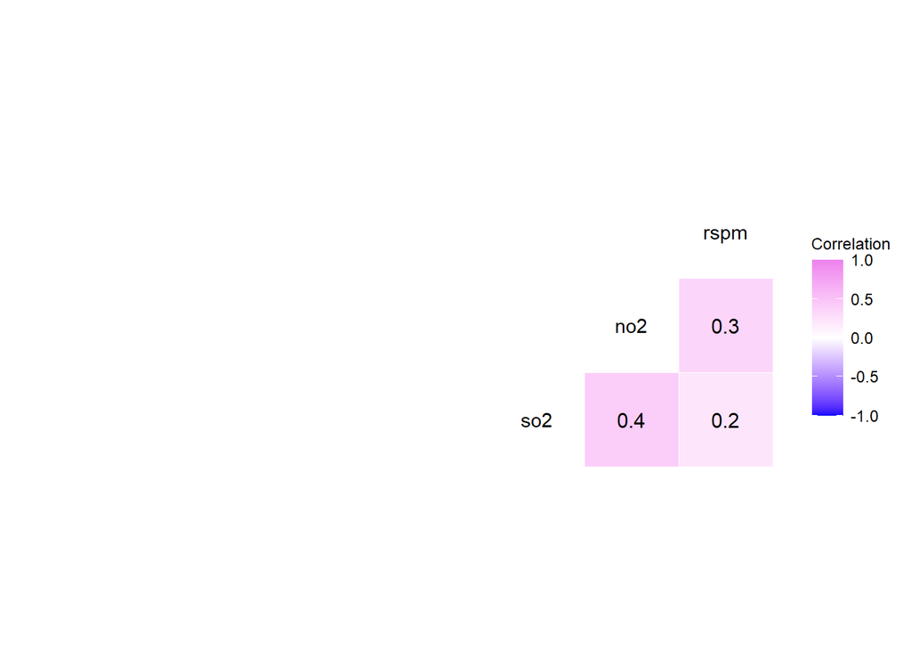

```r
num_data <- data %>%select_if(is.numeric)
ggcorr(num_data, label = T, color = "black",layout.exp = 5,low = "blue", mid = "white", high = "violet",name = "Correlation")
```

### General statistics

```r
library(e1071)
library(tigerstats)
cat("Quantile ranges\n")
```

```
## Quantile ranges
```

```r
quantile(data$rspm)
```

```
##   0%  25%  50%  75% 100%
##    0   56   84  122  255
```

```r
cat("IQR function",IQR(data$rspm),"\n")
```

```
## IQR function 66
```

```r
cat("Variance: ",var(data$rspm),"\n")
```

```
## Variance:  2780.916
```

```r
cat("Standard deviation: ",sd(data$rspm),"\n")
```

```
## Standard deviation:  52.73439
```

```r
cat("Second central of rspm: ",moment(m111survey$height, order=2, center=TRUE))
```

[output not shown]

```r
cat("Skewness: ",skewness(data$rspm),"\n")
```

```
## Skewness:  0.9230205
```

```r
cat("Kurtosis: ",kurtosis(data$rspm),"\n")
```

```
## Kurtosis:  0.356967
```

```r
library(corrplot)
library(RColorBrewer)
data$state<-as.factor(data$state)
data$location<-as.factor(data$location)
data$agency<-as.factor(data$agency)
data$type<-as.factor(data$type)
data$date<-as.factor(data$date)
data$location_monitoring_station<-as.factor(data$location_monitoring_station)
data<-sapply(data,unclass)
```

```r
library("ggpubr")
```

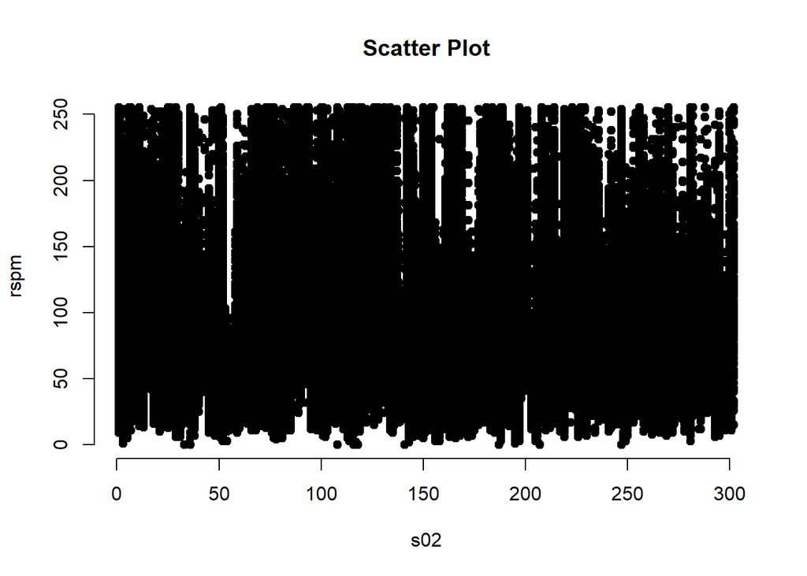

```r
cols<-list("state","location","agency","type","so2","no2","rspm","location_monitoring_station")
data<-as.data.frame(data)
plot(data$location, data$rspm, main = "Scatter Plot",xlab = "s02", ylab = "rspm",pch = 19, frame = FALSE)
```

### Dividing the trainig and testing data

```r
sample <- sample(1:nrow(data), ceiling(0.8*nrow(data)))
train <- data[sample,]
head(train)
```

```
##        state location agency type  so2  no2 rspm location_monitoring_station
## 187202    19      188     32    5  7.2 20.0   34                         622
## 280726    26      165     45    2  6.0 11.0   71                         911
## 238237    22       48     36    6  2.0  5.0   18                         199
## 264624    26      120     44    6 19.1 25.0   84                         744
## 69880     10      206     32    5  2.8 17.3   70                         617
## 266866    26       94     32    3  9.5 22.7  203                         721
##        date
## 187202 3654
## 280726 2411
## 238237  387
## 264624  153
## 69880  4049
## 266866  242
```

```r
test <- data[-sample,]
head(test)
```

```
##    state location agency type  so2  no2 rspm location_monitoring_station date
## 7      1      114     32    6  5.4 17.1   84                         744   88
## 12     1      114     32    6  3.9 14.1   84                         744  143
## 15     1      114     32    6  3.9  8.2   84                         744  171
## 18     1      114     32    6  4.0  9.9   84                         744  198
## 19     1      114     32    2 12.4 11.5   84                         744  198
## 23     1      114     32    6  7.7 11.3   84                         744  253
```

```r
test <- data[-sample,]
head(test)
```

```
##    state location agency type  so2  no2 rspm location_monitoring_station date
## 7      1      114     32    6  5.4 17.1   84                         744   88
## 12     1      114     32    6  3.9 14.1   84                         744  143
## 15     1      114     32    6  3.9  8.2   84                         744  171
## 18     1      114     32    6  4.0  9.9   84                         744  198
## 19     1      114     32    2 12.4 11.5   84                         744  198
## 23     1      114     32    6  7.7 11.3   84                         744  253
```

```r
model <- lm(rspm~state+location+agency+type+so2+no2+location_monitoring_station, data = train)
summary(model)
```

```
##
## Call:
## lm(formula = rspm ~ state + location + agency + type + so2 +
##     no2 + location_monitoring_station, data = train)
##
## Residuals:
##      Min       1Q   Median       3Q      Max
## -141.834  -33.559   -7.858   24.747  193.111
##
## Coefficients:
##                               Estimate Std. Error t value Pr(>|t|)
## (Intercept)                 63.8994081  0.4303871 148.470  < 2e-16 ***
## state                        0.5398839  0.0131484  41.061  < 2e-16 ***
## location                    -0.0577649  0.0010314 -56.008  < 2e-16 ***
## agency                      -0.0101630  0.0086073  -1.181 0.237706
## type                        -1.3703491  0.0491477 -27.882  < 2e-16 ***
## so2                          0.8848461  0.0177049  49.978  < 2e-16 ***
## no2                          1.3316688  0.0088888 149.814  < 2e-16 ***
## location_monitoring_station -0.0010657  0.0003194  -3.337 0.000848 ***
## ---
## Signif. codes:  0 '***' 0.001 '**' 0.01 '*' 0.05 '.' 0.1 ' ' 1
##
## Residual standard error: 48.7 on 305242 degrees of freedom
## Multiple R-squared:  0.1493, Adjusted R-squared:  0.1493
## F-statistic:  7653 on 7 and 305242 DF,  p-value: < 2.2e-16
```

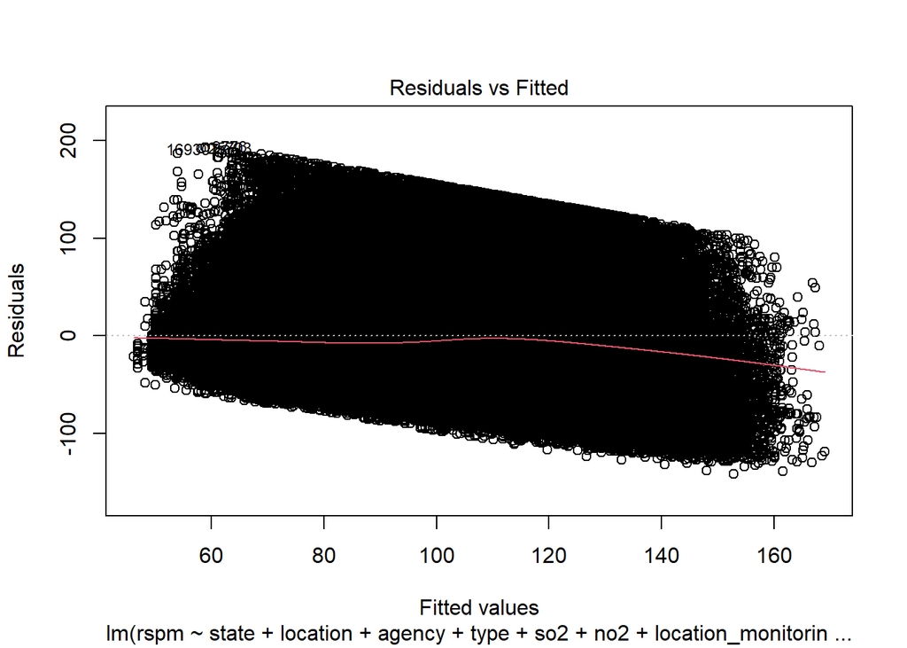

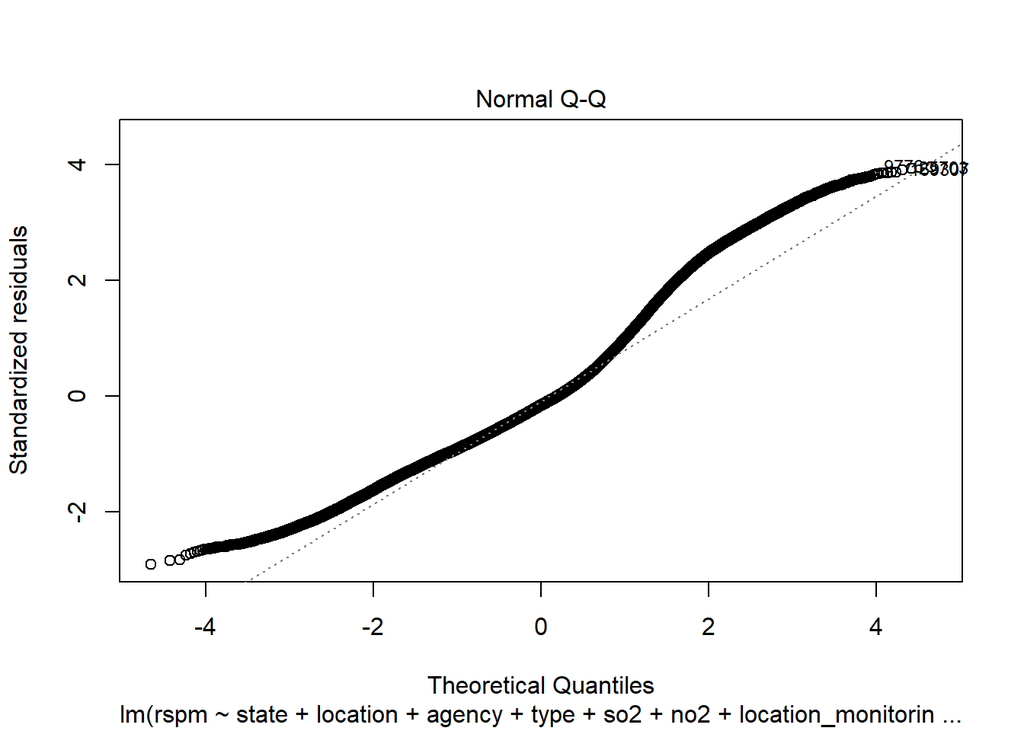

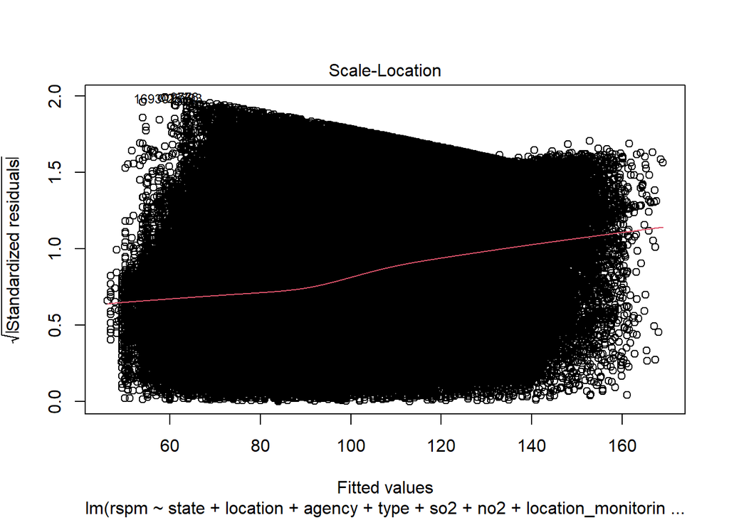

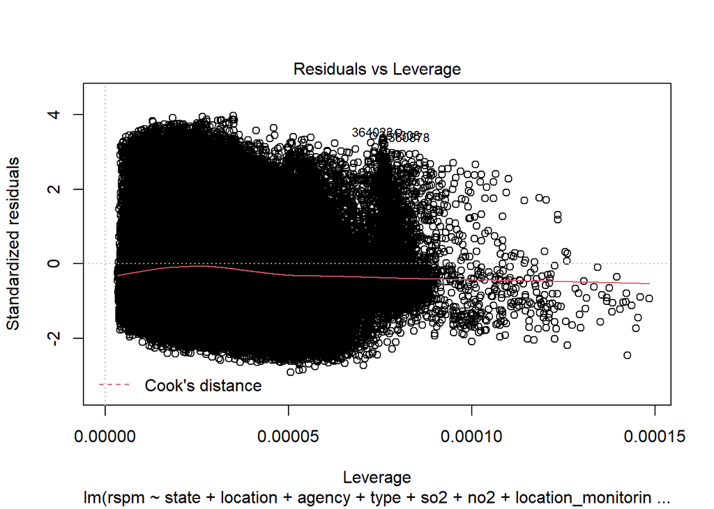

```r
plot(model)
```

### Predicting the value using the built linear model and finding the errors in the prediction

```r
pred <- predict(model,test)
library(caret)
cat("R2 value is: ",R2(pred, test$rspm))
```

```
## R2 value is:  0.1484461
```

```r
cat("RMSE value is: ",rmse(pred, test$rspm))
```

```
## RMSE value is:  48.43271
```

```r
cat("MAE value is: ",mae(pred,test$rspm))
```

```
## MAE value is:  37.52295
```

### Since the errors are way too high, this can’t be a perfect dataset which can be used for prediction. The variables are not correlated even after removing the outliers and further data cleaning.

### But certain analysis can be made which are plotted above